# Two-way ANOVA

2025

## Two-way ANOVA

- Two-way ANOVA is used to determine if there are **any** differences between the means of at least two (but usually three or more) independent groups based on **two** categorical independent variables.
- Like one-way ANOVA, it’s a test for equality of means that uses variances under the hood for inference.
- All ANOVAs are **omnibus** tests. If the test is significant, we know that at least one group is different from the others, but **NOT** which groups are different.

## Example

- Study investigating the effect of sleep deprivation and calorie restriction on cognitive performance.
- **Independent Variable 1**: Amount of sleep (categorical with three levels, such as “Full 8 hours,” “4 hours,” and “No sleep”).
- **Independent Variable 2**: Amount of calorie restriction (categorical with two levels, such as “less than 1000 calories per day” and “more than 2000 calories per day”).
- **Dependent Variable**: Performance on a cognitive task measured by scores on a memory test or reaction times (measurement needs to be continuous).

## Two-way ANOVA Intuition

- If between-group variation is much greater than within-group variation then different groups have different means.
- Two-way ANOVA isn’t as simple as one-way ANOVA because there are many groups for observations to fall between or within.
- The key is to see that a two-way ANOVA is actually testing three null hypotheses simultaneously.

## Two-way ANOVA: Hypotheses

1. Do different levels of factor 1 lead to different outcomes?
2. Do different levels of factor 2 lead to different outcomes?
3. Does the effect of factor 1 depend on the level of factor 2?

## Factor A Hypotheses

- **Null Hypothesis (\(H_0\)):** The means across all levels of factor A are equal:

  \[ \mu_{A1} = \mu_{A2} = \mu_{A3} = \ldots \]
- **Alternative Hypothesis (\(H_1\)):** At least one level mean of factor A is different from the others.

## Factor B Hypotheses

- **Null Hypothesis (\(H_0\)):** The means across all levels of factor B are equal.

  \[ \mu_{B1} = \mu_{B2} = \mu_{B3} = \ldots \]
- **Alternative Hypothesis (\(H_1\)):** At least one level mean of factor B is different from the others.

## Interaction Hypotheses

- The interaction test evaluates whether **the effect of one factor depends on the level of the other factor**.
- **Null Hypothesis (\(H_0\)):** There is **no interaction** between Factor A and Factor B. That is, the effect of Factor A is the same at all levels of Factor B, and vice versa.
- This means the mean response for each combination of A and B can be explained by adding together the main effects of A and B:

\[ \mu_{A_i, B_j} = \mu_{A_i} + \mu_{B_j} \quad \text{for all } i, j \]

- **Alternative Hypothesis (\(H_1\)):** There is an interaction. The effect of Factor A changes depending on the level of Factor B.

## Significant main effect of factor A

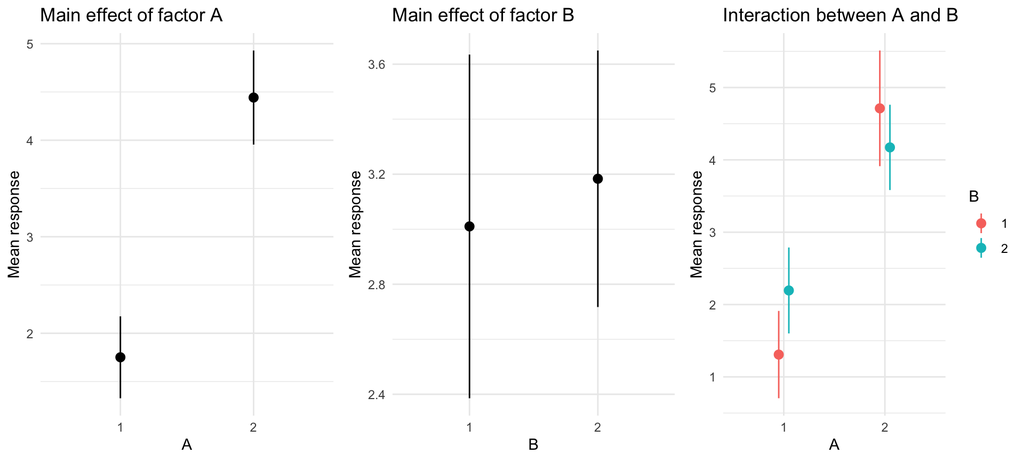

## Significant main effect of factor B

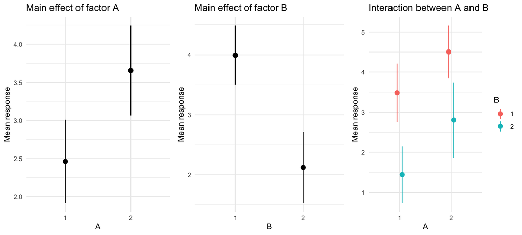

## Significant Interaction between A and B

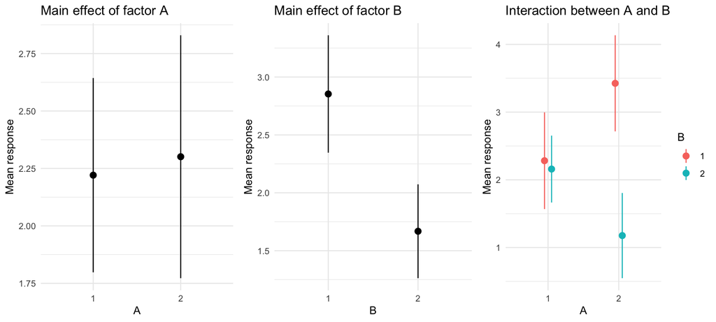

## Summary: Main effect and interaction

- Significant main effects: Group by the factor of interest, average over the other factor, and look for differences in the resulting means.
- Significant interaction: Group by both factors and **look for non-parallel lines.**

## Two-way ANOVA using `ezANOVA`

```
##               y      A      B subject
##           <num> <fctr> <fctr>   <int>
##  1:  1.88694474      1      1       1
##  2:  1.36492952      1      1       2
##  3: -0.08115386      1      1       3
##  4:  4.24272238      1      1       4
##  5:  2.83496984      1      1       5
##  6:  5.21274486      1      1       6
##  7:  3.47051621      1      1       7
##  8: -2.51145118      1      1       8
##  9:  2.71839962      1      1       9
## 10:  3.68580586      1      1      10
## 11:  0.95457162      1      2      11
## 12: -0.30936741      1      2      12
## 13:  3.63590984      1      2      13
```

[output cut: 28 more lines]

```r
dd[, A := factor(A)]
dd[, B := factor(B)]
dd[, subject := factor(subject)]
ezANOVA(data=dd, dv=y, wid=subject, between=.(A, B))
```

```
## $ANOVA
##   Effect DFn DFd          F         p p<.05          ges
## 1      A   1  36 0.01559755 0.9013053       0.0004330776
## 2      B   1  36 3.40313410 0.0733128       0.0863670919
## 3    A:B   1  36 2.73199993 0.1070523       0.0705359893
##
## $`Levene's Test for Homogeneity of Variance`
##   DFn DFd       SSn      SSd         F         p p<.05
## 1   3  36 0.7209457 61.54506 0.1405693 0.9350293
```

## Reporting a two-way ANOVA

```
  Effect DFn DFd           F            p p<.05          ges
1      A   1  36  0.39357521 0.5343852052       0.0108144147
2      B   1  36  0.03322773 0.8563818866       0.0009221413
3    A:B   1  36 16.15655987 0.0002847749     * 0.3097704279
```

## Reporting a two-way ANOVA

A two-way analysis of variance was conducted to examine the effects of factors A and B, as well as their interaction (A:B), on the dependent variable. The analysis yielded a non-significant main effect of factor A, \(F(1, 36) = 0.394, p = .534\), with a very small effect size (\(\eta^2_p = 0.011\)). Similarly, the main effect of factor B was also non-significant, \(F(1, 36) = 0.033, p = .856\), with a negligible effect size (\(\eta^2_p = 0.001\)). However, the interaction effect between factors A and B was found to be statistically significant, \(F(1, 36) = 16.157, p < .001\), indicating a substantial effect (\(\eta^2_p = 0.310\)). This suggests that the effect of factor A on the dependent variable depends significantly on the level of factor B.

## Assumptions: One-Way vs Two-Way ANOVA

| Assumption | One-Way ANOVA | Two-Way ANOVA |
| --- | --- | --- |
| Independence | Observations are independent | Same |
| Normality of residuals | Equivalent to normality within each group | Equivalent to normality within each cell |
| Homogeneity of variance | Equal variances across groups | Equal variances across all cells |
| Residual definition | \(Y_{ij} - \bar{Y}_i\) | \(Y_{ijk} - \text{Fitted}_{ij}\) |

- We will come back to define \(\text{Fitted}_{ij}\) in a later lecture.